# Methods Comp Notes

Zayne Sember

3/29/2022

# POLI 204B

## Hypothesis Testing

1. Set some threshold, $\alpha$, at or below which you deem a p-value significant
2. Define the null hypothesis, $H_0$
3. Define the alternative hypothesis, $H_A$, either two-tailed or one-tailed
4. Calculate a test statistic such as Z-score or t-test and check the p-value
5. Draw conclusions

Some hypothesis tests in R

```r
# ONE SAMPLE T-TEST
# How likely is it that the mean of some population from which we take a normal sample, x, is greater than some number, mu?

x <- rnorm(100)
t.test(x, mu=5)
```

```
##
##  One Sample t-test
##
## data:  x
## t = -51.105, df = 99, p-value < 2.2e-16
## alternative hypothesis: true mean is not equal to 5
## 95 percent confidence interval:
##  -0.2336256  0.1575863
## sample estimates:
##   mean of x
## -0.03801966
```

```r
# WELCH TWO-SAMPLE T-TEST
# How likely is it that the means of two populations differ based on two normal samples of equal variance, x and y?

x <- rnorm(100)
y <- rnorm(100)

t.test(x, y)
```

```
##
##  Welch Two Sample t-test
##
## data:  x and y
## t = 0.99891, df = 197.74, p-value = 0.3191
## alternative hypothesis: true difference in means is not equal to 0
## 95 percent confidence interval:
##  -0.1447079  0.4417937
## sample estimates:
##   mean of x   mean of y
##  0.05106429 -0.09747860
```

```r
# TWO PROPORTION Z-TEST
# Is there a significant difference in proportions between two populations given normal samples of them, x and y?

x <- rnorm(100)
y <- rnorm(100)

# Assuming we want to test whether the share of values greater than zero differs between the two populations
x_count <- length(x[x>0])
y_count <- length(y[y>0])

prop.test(x=c(x_count,y_count), n=c(length(x), length(y)), alternative="two.sided")
```

```
##
##  2-sample test for equality of proportions with continuity correction
##
## data:  c(x_count, y_count) out of c(length(x), length(y))
## X-squared = 1.6206, df = 1, p-value = 0.203
## alternative hypothesis: two.sided
## 95 percent confidence interval:
##  -0.04786783  0.24786783
## sample estimates:
## prop 1 prop 2
##   0.56   0.46
```

```r
# CHI-SQUARED TEST
# Are two variables independent? Useful for testing relationships between categorical variables

#  For example, if you were investigating the relationship between occupation and party preference, and 35% of voters were Democrats, 32% were Independents, and 33% were Republicans, independence implies the same partisan breakdown across all occupational categories (35, 32, and 33).

data_frame <- read.csv("https://goo.gl/j6lRXD")

table(data_frame$treatment, data_frame$improvement)
```

```
##
##               improved not-improved
##   not-treated       26           29
##   treated           35           15
```

```r
chisq.test(data_frame$treatment, data_frame$improvement, correct=FALSE)
```

```
##
##  Pearson's Chi-squared test
##
## data:  data_frame$treatment and data_frame$improvement
## X-squared = 5.5569, df = 1, p-value = 0.01841
```

```r
# DIFFERENCE BETWEEN VARIANCES TEST
# Is the variance between two normal samples, x and y, drawn from populations significantly different?

x <- rnorm(100, sd=3)
y <- rnorm(121, sd=3.5)

var.test(x, y)
```

```
##
##  F test to compare two variances
##
## data:  x and y
## F = 0.7288, num df = 99, denom df = 120, p-value = 0.1039
## alternative hypothesis: true ratio of variances is not equal to 1
## 95 percent confidence interval:
##  0.5009659 1.0676423
## sample estimates:
## ratio of variances
##          0.7288005
```

## Properties of Estimators

### Unbiasedness

$E(\hat{\theta}) - \theta = 0$

### Asymptotic Unbiasedness

As $n$ gets bigger, the estimator’s biasedness goes to zero $\lim_{n\to\infty} P(|E[\hat{\theta}] - \theta| > \epsilon) \to 0; \forall\epsilon >0$

### Efficiency

The estimator needs fewer observations to achieve better error performance $\frac{1}{MSE}=\frac{1}{E[(\hat{\theta}-\theta)^2]}$

### Consistency

The distribution of estimates converges on the true value as $n$ gets bigger $\lim_{n\to\infty} P(|\hat{\theta} - \theta| > \epsilon) \to 0; \forall\epsilon >0$

## Correlation

We define the correlation, $r$, between two variables, $x$ and $y$, to be:

$$r=\frac{\sum{Z_{xi}Z_{yi}}}{n-1}=\frac{\sum{(x_i-\bar{x})(y_i-\bar{y})}}{s_xs_y(n-1)}$$
where the standard deviation of $x$ (and same for $y$) is:

$$s_x=\sqrt{\frac{\sum{(x_i-\bar{x})^2}}{n-1}}$$

```r
x <- rnorm(n=100, mean=2, sd=3)
y <- rnorm(n=100, mean=-3, sd=2)

cor(x,y)
```

```
## [1] 0.003104286
```

## Regression Basics

Ordinary least squares regression seeks to minimize the the vertical distances, $\epsilon$, between the data being fitted and some line of best fit with some slope (in the bivariate case), $\beta_1$, and some intercept, $\beta_0$.

The model we want to fit to:

$$y_i=\beta_0+\beta_1x_i+\epsilon_i$$

The model we estimate:

$$y_i=\hat{\beta_0}+\hat{\beta_1}x_i+e_i$$
The residuals, $e_i$, are an estimate of the error (distance between true line and y_i).

The residual sum of squares (RSS) is defined as:
$$RSS=\sum e_i^2=\sum(y_i-\hat{y_i})^2$$

```r
# If we have some lm model we can get the RSS as follows:
x <- rnorm(n=100, mean=2, sd=3)
y <- rnorm(n=100, mean=-3, sd=2)

model <- lm(y ~ x)

deviance(model)
```

```
## [1] 417.752
```

```r
# or

sum(resid(model)^2)
```

```
## [1] 417.752
```

```r
# Or without an lm model:

rss <- function(y, y_hat){
  return(sum((y-y_hat)^2))
}

y_hat <- fitted(model)

rss(y, y_hat)
```

```
## [1] 417.752
```

The regression sum of squares (RSS) (AKA sum of squares of regression (SSR), explained sum of squares (ESS)) is defined as:
$$RegSS=\sum(\hat{y_i}-\bar{y})^2$$

```r
x <- rnorm(n=100, mean=2, sd=3)
y <- rnorm(n=100, mean=-3, sd=2)

model <- lm(y ~ x)

y_hat <- fitted(model)

regSS <- function(y_hat, y){
  return(sum((y_hat-mean(y))^2))
}

regSS(y_hat, y)
```

```
## [1] 0.01606493
```

The total sum of squares (TSS) is defined as:
$$TSS=\sum(y_i-\bar{y})^2$$

```r
y <- rnorm(n=100, mean=-3, sd=2)

TSS <- function(y){
  return(sum((y-mean(y))^2))
}

TSS(y)
```

```
## [1] 407.0087
```

The ratio of RegSS to TSS is our $r^2$, the share of variance in $y$ that is explained by $x$:
$$r^2=\frac{RegSS}{TSS}=\frac{\sum(\hat{y_i}-\bar{y})^2}{\sum(y_i-\bar{y})^2}$$

```r
x <- rnorm(n=100, mean=2, sd=3)
y <- rnorm(n=100, mean=-3, sd=2)

model <- lm(y ~ x)

summary(model)$r.squared
```

```
## [1] 5.390968e-06
```

```r
# or

y_hat <- fitted(model)

rsquared <- function(y, y_hat){
  return(sum((y_hat-mean(y))^2)/sum((y-mean(y))^2))
}

rsquared(y, y_hat)
```

```
## [1] 5.390968e-06
```

### Calculating bivariate regression by hand (linear method)

#### Step 1

Given the vectors $X$ and $Y$, find $X^2$, $XY$, and the sums of all of the preceding vectors

```r
calc_x2xy <- function(x, y){
  df <- data.frame(x=x,y=y)

  df$xsquared <- x^2
  df$xy <- x*y

  totals <- c(sum(x), sum(y), sum(df$xsquared), sum(df$xy))

  df <- rbind(df, totals)
  rownames(df) <- c(1:length(x),"total")

  return(df)
}

x <- rnorm(n=7, mean=2, sd=3)
y <- rnorm(n=7, mean=-3, sd=2)

df_step1 <- calc_x2xy(x=x,y=y)
df_step1
```

```
##                 x           y     xsquared           xy
## 1     -0.89465369  -5.0657054 8.004052e-01   4.53205200
## 2      7.19326490  -3.0530456 5.174306e+01 -21.96136581
## 3      5.34976489  -5.7590529 2.861998e+01 -30.80957905
## 4      3.26727729  -4.2740657 1.067510e+01 -13.96455781
## 5      0.01825773  -3.5787442 3.333447e-04  -0.06533974
## 6     -1.83685201   1.1036368 3.374025e+00  -2.02721756
## 7      4.13996638  -0.6039172 1.713932e+01  -2.50019694
## total 17.23702550 -21.2308942 1.123522e+02 -66.79620490
```

#### Step 2

Calculate $\hat\beta_1$ and $\hat\beta_0$:
$$\hat\beta_1=\frac{N\sum x_iy_i-\sum x_i\sum y_i}{N\sum x_i^2-(\sum x_i)^2}$$
$$\hat\beta_0=\frac{\sum y_i -\hat\beta_1\sum x_i}{N}$$

```r
calc_beta1 <- function(df){
  totals <- tail(df,n=1)
  N <- length(df[[1]])-1

  df <- head(df,n=N)
  N <- length(df$x-1) # -1 bc row totals amended

  beta1 <- (N*totals$xy - (totals$x*totals$y))/((N*totals$xsquared)-(totals$x)^2)
  return(beta1)
}

calc_beta0 <- function(df, beta1){
  totals <- tail(df,n=1)
  N <- length(df[[1]])-1

  beta0 <- (totals$y - (beta1*totals$x))/N
  return(beta0)
}

beta1 <- calc_beta1(df=df_step1)
beta1
```

```
## [1] -0.2076548
```

```r
beta0 <- calc_beta0(df=df_step1, beta1=beta1)
beta0
```

```
## [1] -2.521649
```

```r
# check with:
# lm(y~x)
```

#### Step 3

Next, calculate $x-\bar x$, $(x- \bar x)^2$, $y-\bar y$, $(y-\bar y)^2$, and $(x-\bar x)(y-\bar y)$.

```r
calc_r_table <- function(x, y){
  N <- length(x)
  df <- data.frame(x=x,y=y)

  df$x_minus_xbar <- df$x -  mean(x)
  df$x_minus_xbar_sq <- (df$x_minus_xbar)^2

  df$y_minus_ybar <- df$y -  mean(y)
  df$y_minus_ybar_sq <- (df$y_minus_ybar)^2

  df$x_minus_xbar_y_minus_ybar <- df$x_minus_xbar*df$y_minus_ybar

  return(df)
}

calc_rsquared <- function(x, y){
  df <- calc_r_table(x,y)
  N <- length(x)

  sd_x <- sqrt((sum(df$x_minus_xbar_sq))/(N-1))
  sd_y <- sqrt((sum(df$y_minus_ybar_sq))/(N-1))

  r <- (sum(df$x_minus_xbar_y_minus_ybar))/((N-1)*sd_x*sd_y)

  return(r^2)
}

calc_r_table(x=x,y=y)
```

```
##             x          y x_minus_xbar x_minus_xbar_sq y_minus_ybar
## 1 -0.89465369 -5.0657054   -3.3570859      11.2700257  -2.03272052
## 2  7.19326490 -3.0530456    4.7308327      22.3807779  -0.02006073
## 3  5.34976489 -5.7590529    2.8873327       8.3366900  -2.72606803
## 4  3.26727729 -4.2740657    0.8048451       0.6477756  -1.24108083
## 5  0.01825773 -3.5787442   -2.4441745       5.9739889  -0.54575929
## 6 -1.83685201  1.1036368   -4.2992842      18.4838449   4.13662172
## 7  4.13996638 -0.6039172    1.6775342       2.8141209   2.42906767
##   y_minus_ybar_sq x_minus_xbar_y_minus_ybar
## 1    4.131953e+00                6.82401740
## 2    4.024328e-04               -0.09490395
## 3    7.431447e+00               -7.87106530
## 4    1.540282e+00               -0.99887779
## 5    2.978532e-01                1.33393094
## 6    1.711164e+01              -17.78451252
## 7    5.900370e+00                4.07484401
```

```r
calc_rsquared(x=x,y=y)
```

```
## [1] 0.08278241
```

```r
# check with:
#summary(lm(y~x))$r.squared
```

#### Step 4

Calculate the residuals, their square, and from that the estimated standard error
$$e_i=y_i-\hat y_i=y_i-\hat\beta_0-\hat\beta_1 x_i$$
$$\hat\sigma=\sqrt{\frac{\sum e_i^2}{N-2}}$$

```r
calc_residuals <- function(x, y, beta0, beta1){
  df <- data.frame(e=y-beta0-(beta1*x))
  df$e_squared <- df$e^2

  return(df)
}

calc_sigma <- function(e_squared, N){
  return(sqrt(sum(e_squared)/(N-2)))
}

residuals <- calc_residuals(x, y, beta0, beta1)
residuals
```

```
##            e  e_squared
## 1 -2.7298354  7.4520011
## 2  0.9623192  0.9260582
## 3 -2.1264997  4.5220009
## 4 -1.0739509  1.1533706
## 5 -1.0533037  1.1094488
## 6  3.2438549 10.5225948
## 7  2.7774156  7.7140375
```

```r
# check with:
#resid(lm(y~x))

sigma <- calc_sigma(residuals$e_squared, N=length(x))
sigma
```

```
## [1] 2.584551
```

```r
# check with:
#summary(lm(y~x))$sigma
```

### Calculating bivariate regression by hand (matrix method)

Just calculate $\hat\beta=(X'X)^{-1}X'Y$

```r
x <- rnorm(n=7, mean=2, sd=3)
y <- rnorm(n=7, mean=-3, sd=2)

print("Append ones to X")
```

```
## [1] "Append ones to X"
```

```r
X <- matrix(c(rep(1, length(x)),x), nrow=length(x))
X
```

```
##      [,1]       [,2]
## [1,]    1  1.2251664
## [2,]    1  1.8900956
## [3,]    1 -0.6234058
## [4,]    1  3.2910001
## [5,]    1  6.5006277
## [6,]    1  2.2706807
## [7,]    1 -1.0890884
```

```r
print("Define Y")
```

```
## [1] "Define Y"
```

```r
Y <- as.matrix(y)
Y
```

```
##            [,1]
## [1,] -3.7441443
## [2,] -7.2401623
## [3,] -5.1607332
## [4,]  0.7630961
## [5,] -5.6934331
## [6,] -4.6923023
## [7,] -0.6773199
```

```r
print("Get X'X")
```

```
## [1] "Get X'X"
```

```r
t(X) %*% X
```

```
##          [,1]     [,2]
## [1,]  7.00000 13.46508
## [2,] 13.46508 64.89308
```

```r
print("Get the inversion of X'X")
```

```
## [1] "Get the inversion of X'X"
```

```r
solve(t(X) %*% X)
```

```
##             [,1]        [,2]
## [1,]  0.23775300 -0.04933288
## [2,] -0.04933288  0.02564636
```

```r
print("Get X'Y")
```

```
## [1] "Get X'Y"
```

```r
t(X) %*% Y
```

```
##           [,1]
## [1,] -26.44500
## [2,] -59.47117
```

```r
print("Get beta")
```

```
## [1] "Get beta"
```

```r
solve(t(X) %*% X) %*% t(X) %*% Y
```

```
##            [,1]
## [1,] -3.3534939
## [2,] -0.2206108
```

```r
# check with:
#lm(y~x)
```

## Multiple Regression

We now have multiple $X$s we need to fit to:

$$Y=\beta_0+\beta_1X_1+\beta_2X_2+\epsilon$$

We want to find the values of $\beta_0$, $\beta_1$, and $\beta_2$ that **minimizes** the sum of squared residuals (RSS):

## Categorical Variables

When regressing on a categorical variable you leave one category out. Coefficients are the impact of being $X$ vs. the excluded category, all else equal.

## Fixed Effects

Suppose we have data on 100 individuals in each of 100 countries ($n=10,000$).

```r
data(trade)

# Without fixed effects
ols <- lm(log(Euros) ~ log(dist_km), data=trade)

summary(ols)
```

```
##
## Call:
## lm(formula = log(Euros) ~ log(dist_km), data = trade)
##
## Residuals:
##      Min       1Q   Median       3Q      Max
## -15.6809  -1.7347   0.5372   2.1699   7.1905
##
## Coefficients:
##              Estimate Std. Error t value Pr(>|t|)
## (Intercept)  28.32169    0.16962  166.97   <2e-16 ***
## log(dist_km) -1.90965    0.02401  -79.54   <2e-16 ***
## ---
## Signif. codes:  0 '***' 0.001 '**' 0.01 '*' 0.05 '.' 0.1 ' ' 1
##
## Residual standard error: 2.977 on 38323 degrees of freedom
## Multiple R-squared:  0.1417, Adjusted R-squared:  0.1417
## F-statistic:  6326 on 1 and 38323 DF,  p-value: < 2.2e-16
```

```r
# With fixed effects by country of origin and destination, product, and year
fe_ols <- feols(log(Euros) ~ log(dist_km) | Origin + Destination + Product + Year, trade)

summary(fe_ols)
```

```
## OLS estimation, Dep. Var.: log(Euros)
## Observations: 38,325
## Fixed-effects: Origin: 15,  Destination: 15,  Product: 20,  Year: 10
## Standard-errors: Clustered (Origin)
##              Estimate Std. Error  t value   Pr(>|t|)
## log(dist_km) -2.16988   0.154283 -14.0642 1.1898e-09 ***
## ---
## Signif. codes:  0 '***' 0.001 '**' 0.01 '*' 0.05 '.' 0.1 ' ' 1
## RMSE: 1.74337     Adj. R2: 0.705139
##                 Within R2: 0.219322
```

## Interactions

Case 1: Interacting a dummy with another dummy - Coefficient is the (estimated) change in the *intercept* of the line of best fit between units where both dummies are zero vs. where they are both 1.

Case 2: Interacting a dummy with a continuous variable - Coefficient is the difference in coefficient on the continuous variable when dummy is on vs. off.

Case 3: Interacting a continuous variable with another continuous variable. - Don’t try to interpret coefficient, look at an interaction plot

Overall, an interaction tells us the *impact* one variable has on another variable’s effect on the outcome. - Only include them when you have a theoretical reason for doing so

### Interaction plots

```r
set.seed(10)

#create data frame
df <- data.frame(gender = c(0,0,0,1,0,1,1,0,1,0),
                 exercise = c(0,0,2,1,2,0,1,0,2,1),
                 weight_loss = rnorm(n=10,mean=2,sd=3)) %>%
  mutate(motivation = (2.5*weight_loss + rnorm(n=10, mean=3, sd=3)))

head(df)
```

```
##   gender exercise weight_loss motivation
## 1      0        0   2.0562385  11.445935
## 2      0        0   1.4472424   8.885450
## 3      0        2  -2.1139916  -2.999680
## 4      1        1   0.2024969   6.468576
## 5      0        2   2.8836354  12.433259
## 6      1        0   3.1693829  11.191499
```

```r
model <- lm(weight_loss ~ gender*exercise, data=df)
summary(model)
```

```
##
## Call:
## lm(formula = weight_loss ~ gender * exercise, data = df)
##
## Residuals:
##     Min      1Q  Median      3Q     Max
## -2.5614 -0.4690  0.3392  0.4711  2.4362
##
## Coefficients:
##                 Estimate Std. Error t value Pr(>|t|)
## (Intercept)       1.5126     0.8989   1.683    0.143
## gender            1.2290     1.6616   0.740    0.487
## exercise         -0.5326     0.7340  -0.726    0.495
## gender:exercise  -2.4921     1.3567  -1.837    0.116
##
## Residual standard error: 1.614 on 6 degrees of freedom
## Multiple R-squared:  0.6062, Adjusted R-squared:  0.4094
## F-statistic: 3.079 on 3 and 6 DF,  p-value: 0.1119
```

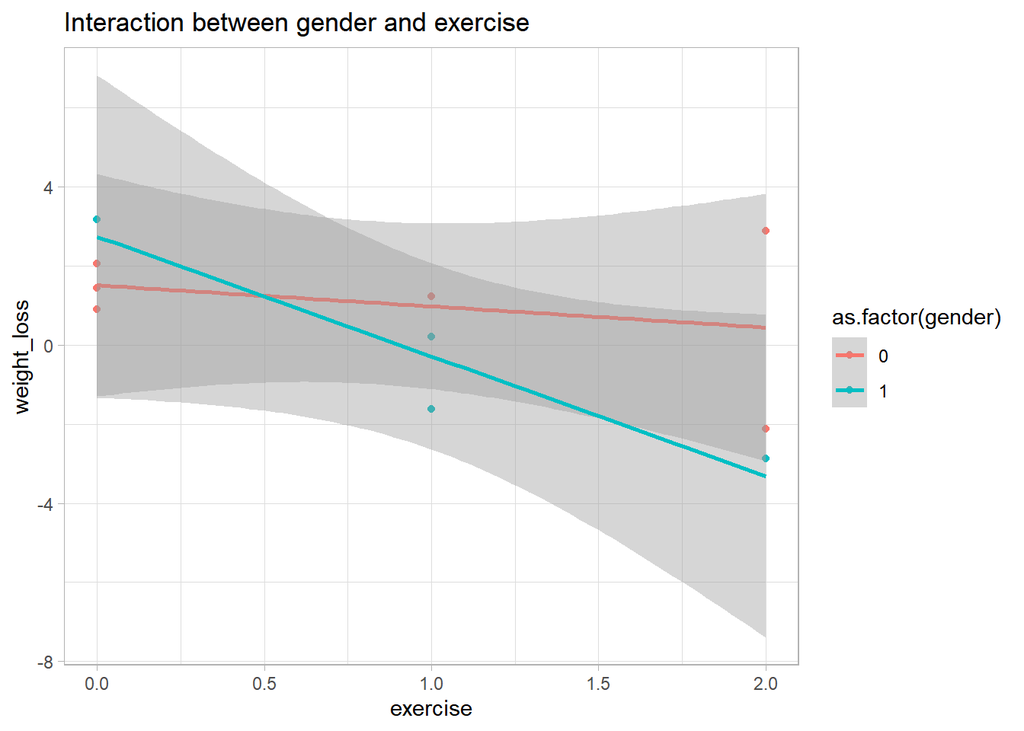

```r
# Plot interaction of gender*exercise
ggplot(data=df, aes(x=exercise, y=weight_loss, color=as.factor(gender))) +
  geom_point() +
  geom_smooth(method="lm") +
  labs(title="Interaction between gender and exercise") +
  theme_light()
```

```r
model <- lm(weight_loss ~ exercise*motivation, data=df)
summary(model)
```

```
##
## Call:
## lm(formula = weight_loss ~ exercise * motivation, data = df)
##
## Residuals:
##      Min       1Q   Median       3Q      Max
## -0.71869 -0.35043 -0.00051  0.32748  0.86701
##
## Coefficients:
##                     Estimate Std. Error t value Pr(>|t|)
## (Intercept)         -0.06532    0.74069  -0.088   0.9326
## exercise            -0.80760    0.46780  -1.726   0.1350
## motivation           0.21156    0.08136   2.600   0.0406 *
## exercise:motivation  0.06580    0.05181   1.270   0.2511
## ---
## Signif. codes:  0 '***' 0.001 '**' 0.01 '*' 0.05 '.' 0.1 ' ' 1
##
## Residual standard error: 0.6528 on 6 degrees of freedom
## Multiple R-squared:  0.9356, Adjusted R-squared:  0.9033
## F-statistic: 29.04 on 3 and 6 DF,  p-value: 0.0005709
```

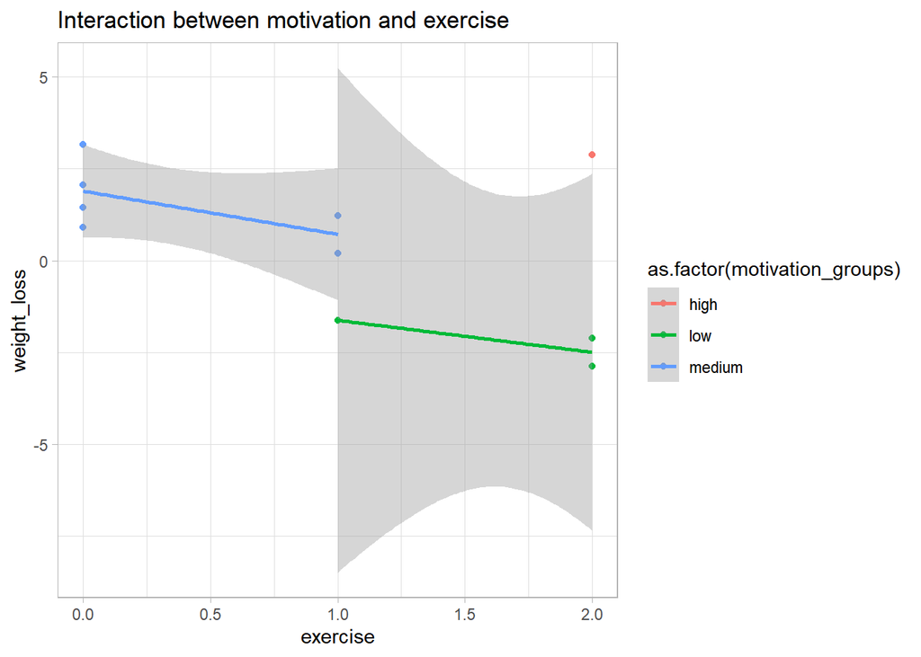

```r
# To visualize an interaction between continuous variables you have to discretize
# one of them, i.e. group those above and below the mean
df$motivation_groups <- case_when(
  df$motivation > mean(df$motivation)+sd(df$motivation) ~ "high",
  df$motivation < mean(df$motivation)+sd(df$motivation) & df$motivation > mean(df$motivation)-sd(df$motivation) ~ "medium",
  df$motivation < mean(df$motivation)-sd(df$motivation) ~ "low"
)

# Can plot the interactions manually

ggplot(data=df, aes(x=exercise, y=weight_loss, color=as.factor(motivation_groups))) +
  geom_point() +
  geom_smooth(method="lm") +
  labs(title="Interaction between motivation and exercise") +
  theme_light()
```

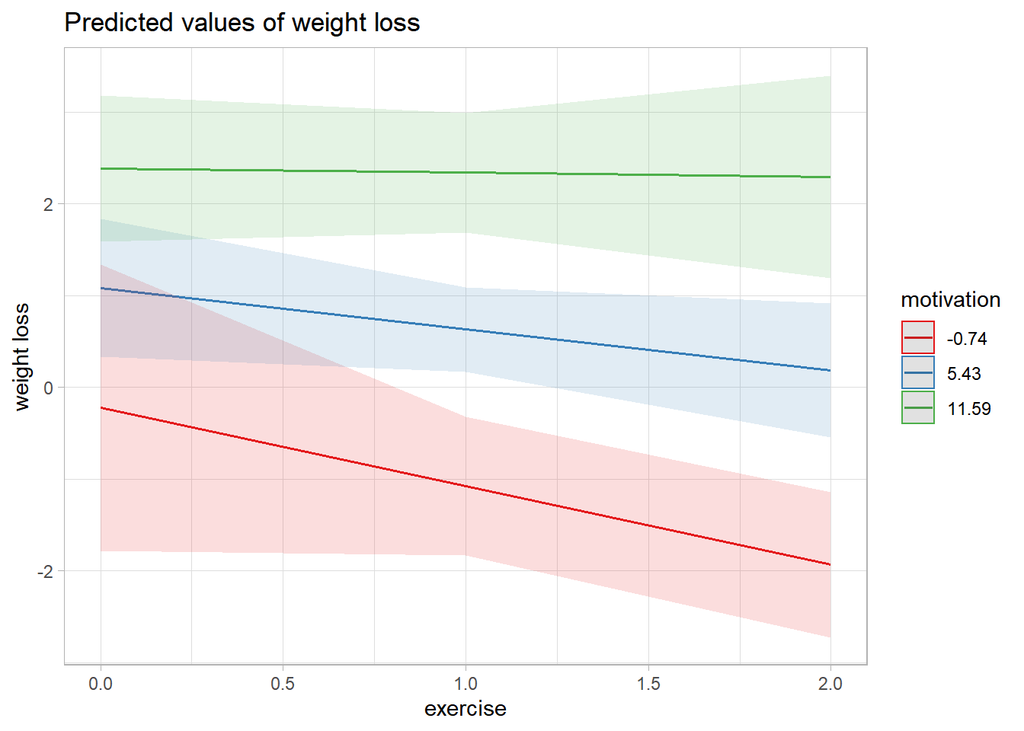

```r
# OR with plot_model
plot_model(model, type = "pred", terms = c("exercise", "motivation")) +
  theme_light()
```

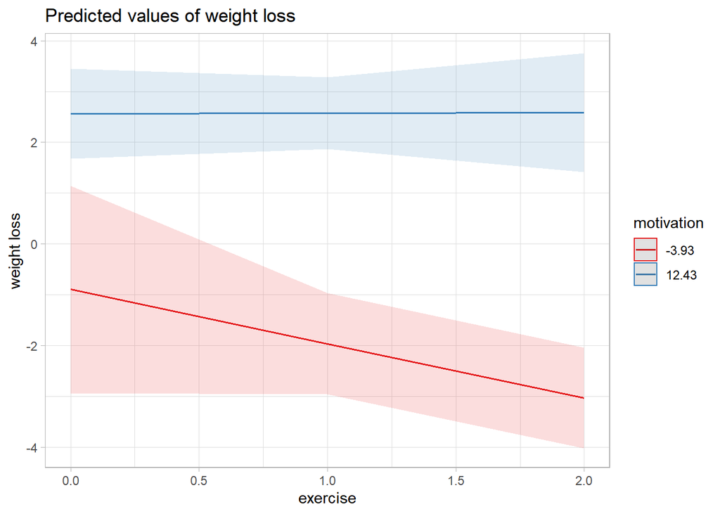

```r
plot_model(model, type = "int") +
  theme_light()
```

## Regression Presentation

### Regression tables

Pretty self-explanatory

### Coefficient Plots

Easier to read than a Big Ugly Table of Numbers (BUTON) - Always include 95% CI

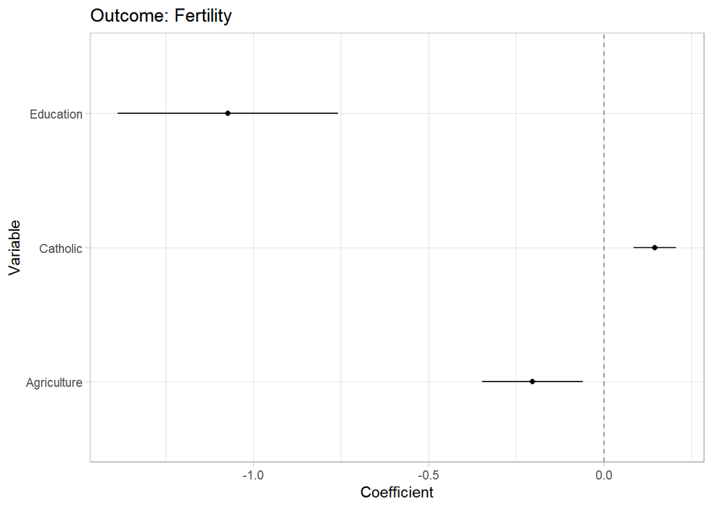

```r
# Source: https://bookdown.org/paul/applied-data-visualization/graph-coefficient-plots.html

fit <- lm(Fertility ~ Catholic + Agriculture + Education, data = swiss) # see ?swiss
results <- tidy(fit)
fit_cis_95 <- confint(fit, level = 0.95) %>%
  data.frame() %>%
  rename("conf.low_95" = "X2.5..",
         "conf.high_95" = "X97.5..")
fit_cis_90 <- confint(fit, level = 0.90) %>%
  data.frame() %>%
  rename("conf.low_90" = "X5..",
         "conf.high_90" = "X95..")
results <- bind_cols(results,
                     fit_cis_95,
                     fit_cis_90) %>%
           rename(Variable = term,
                  Coefficient = estimate,
                  SE = std.error) %>%
           filter(Variable != "(Intercept)")


ggplot(results, aes(x = Variable, y = Coefficient)) +
        geom_hline(yintercept = 0, colour = gray(1/2), lty = 2) +
        geom_point(aes(x = Variable,
                    y = Coefficient)) +
        # geom_linerange(aes(x = Variable,
        #              ymin = conf.low_90,
        #              ymax = conf.high_90),
        #            lwd = 1) +
        geom_linerange(aes(x = Variable,
                     ymin = conf.low_95,
                     ymax = conf.high_95),
                   lwd = 1/2) +
        ggtitle("Outcome: Fertility") +
        coord_flip() +
  theme_light()
```

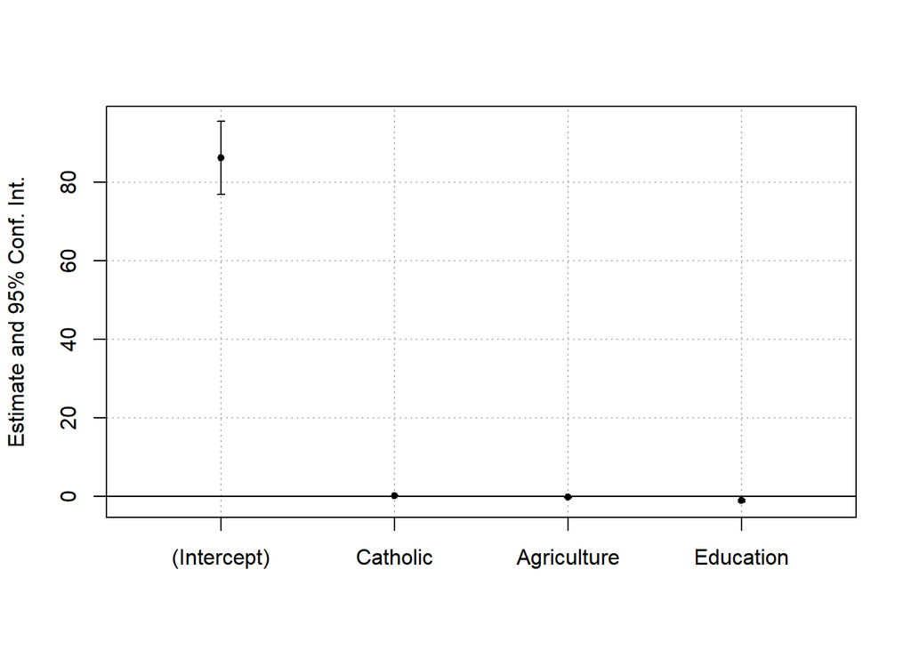

```r
# OR

coefplot(fit)
```

### Predicted Value Plots

These plots convey the substantive importance of your findings; the magnitude of the impact of your IVs on your DV

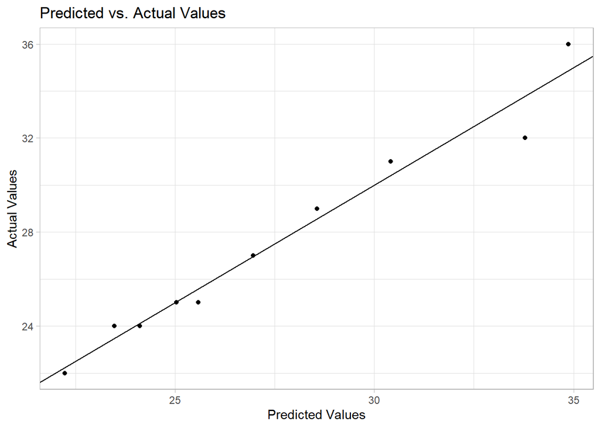

```r
df <- data.frame(x1=c(3, 4, 4, 5, 5, 6, 7, 8, 11, 12),
                 x2=c(6, 6, 7, 7, 8, 9, 11, 13, 14, 14),
                 x3=c(15, 12, 8, 9, 6, 5, 5, 2, 1, 0),
                 y=c(22, 24, 24, 25, 25, 27, 29, 31, 32, 36))

#fit multiple linear regression model
model <- lm(y ~ x1 + x2 +x3, data=df)

#plot predicted vs. actual values
ggplot(df, aes(x=predict(model), y=y)) +
  geom_point() +
  geom_abline(intercept=0, slope=1) +
  labs(x='Predicted Values', y='Actual Values',
       title='Predicted vs. Actual Values') +
  theme_light()
```

### Marginal Effects Plot

Another way to visualize the substantive meaning of your regression coefficients, especially when interactions are involved.

```r
data(efc)
model <- lm(barthtot ~ c12hour + neg_c_7 * c161sex + e42dep, data = efc)

ggpredict(model, terms = "c12hour")
```

```
## # Predicted values of Total score BARTHEL INDEX
##
## c12hour | Predicted |         95% CI
## ------------------------------------
##       0 |     69.02 | [67.30, 70.73]
##      20 |     66.98 | [65.59, 68.37]
##      45 |     64.44 | [63.19, 65.69]
##      65 |     62.41 | [61.00, 63.81]
##      85 |     60.37 | [58.64, 62.10]
##     105 |     58.34 | [56.17, 60.50]
##     125 |     56.30 | [53.66, 58.94]
##     170 |     51.72 | [47.92, 55.52]
##
## Adjusted for:
## * neg_c_7 = 11.83
## * c161sex =  1.76
## *  e42dep =  2.93
```

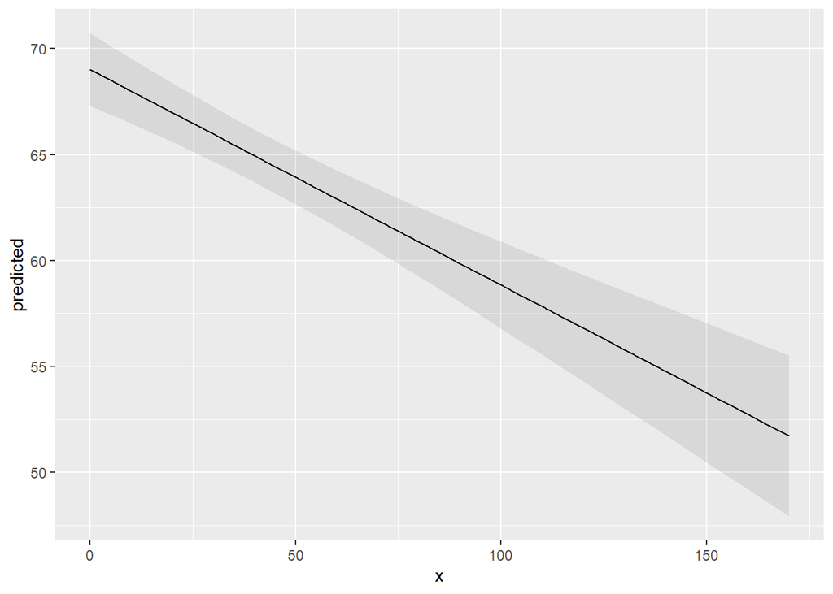

```r
df_predict <- ggpredict(model, terms = "c12hour")
ggplot(df_predict, aes(x, predicted)) +
  geom_line() +
  geom_ribbon(aes(ymin = conf.low, ymax = conf.high), alpha = .1)
```

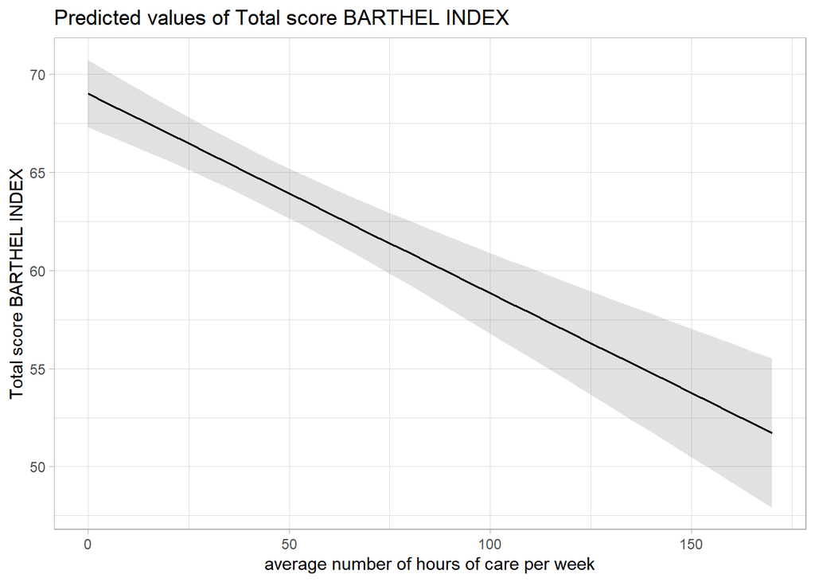

```r
# OR use plot_model
plot_model(model, type = "pred", terms = c("c12hour")) +
  theme_light()
```

## Regression Assumptions and Diagnostics

### Four assumptions of regression

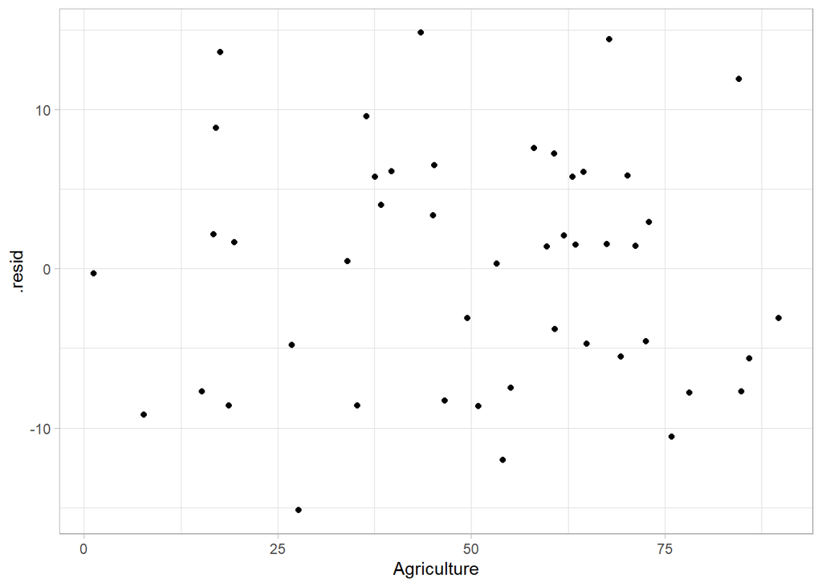

```r
fit <- lm(Fertility ~ Catholic + Agriculture + Education, data = swiss)


# Residuals vs. X
# Ideally want a "cloud" without a large amount of values at the extremes of X, we want it to look basically random

# If we have a U-shape or an inverted U then that indicates the data may be better suited for a nonlinear model

# We also want to check for any major outliers, is there a point that's super far away from the rest?
ggplot(data=fit, aes(x=Agriculture, y=.resid)) +
  geom_point() +
  theme_light()
```

### Leverages

Leverages tell us how much influence each value of $X$ have

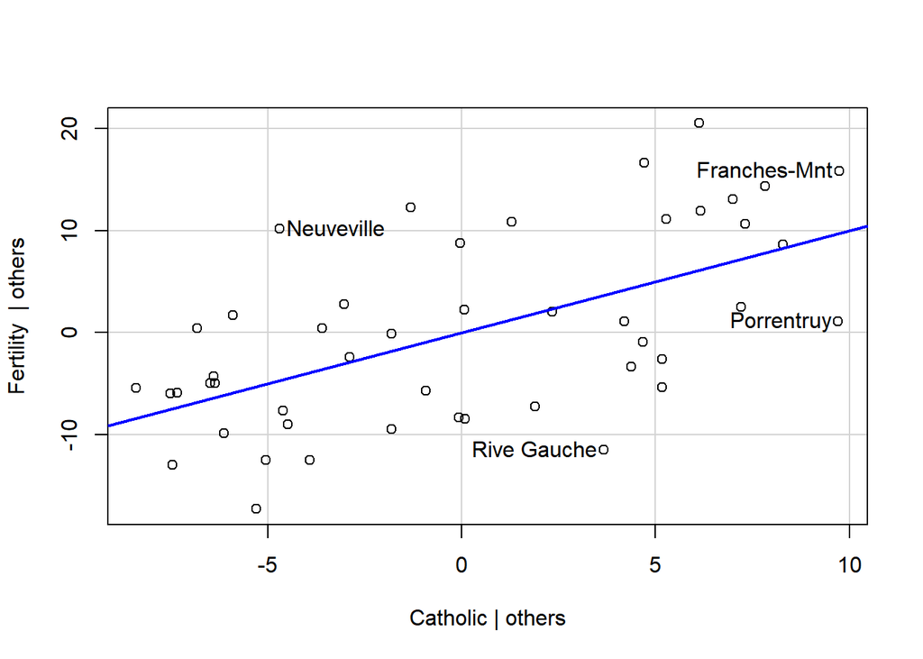

```
##  Rive Gauche   Neuveville Franches-Mnt   Porrentruy
##           47            5            3            6
```

```r
fit <- lm(Fertility ~ Catholic + Agriculture + Education, data = swiss)

leveragePlot(model=fit, term.name="Catholic")
```

### Studentized and Standardized Residuals

Standardized measurements of residuals, helps you see outliers.

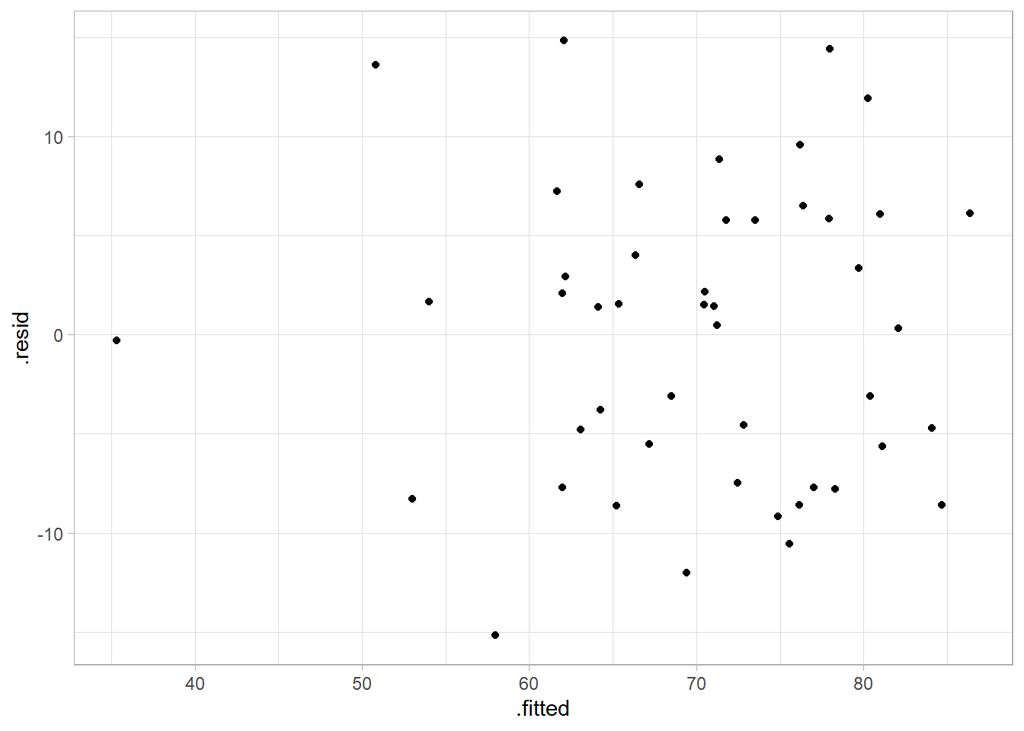

```r
fit <- lm(Fertility ~ Catholic + Agriculture + Education, data = swiss)

# Regular ole residuals
ggplot(data=fit, aes(x=.fitted, y=.resid)) +
  geom_point() +
  theme_light()
```

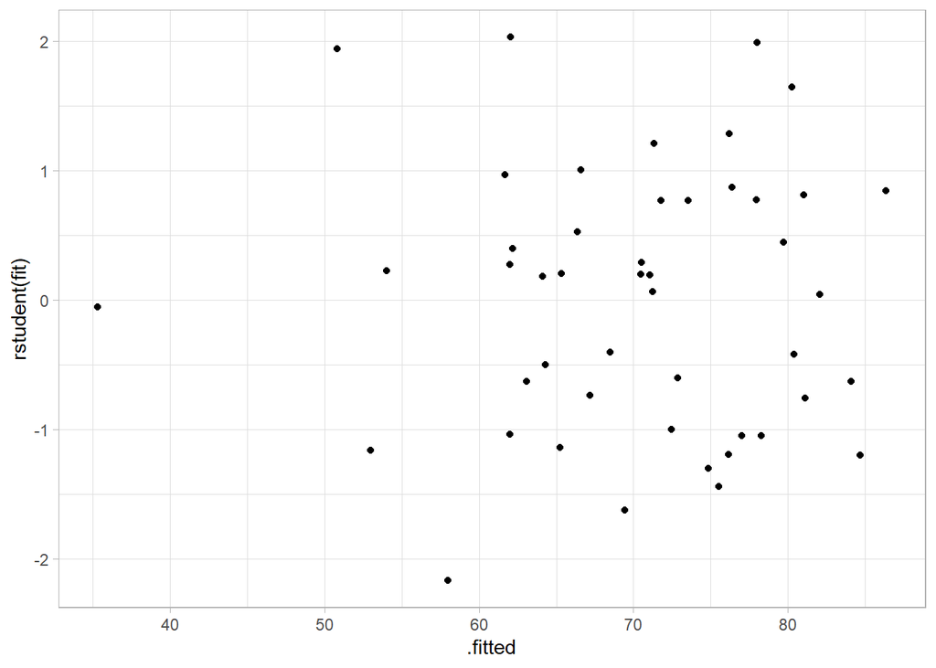

```r
# Studentized residuals
ggplot(data=fit, aes(x=.fitted, y=rstudent(fit))) +
  geom_point() +
  theme_light()
```

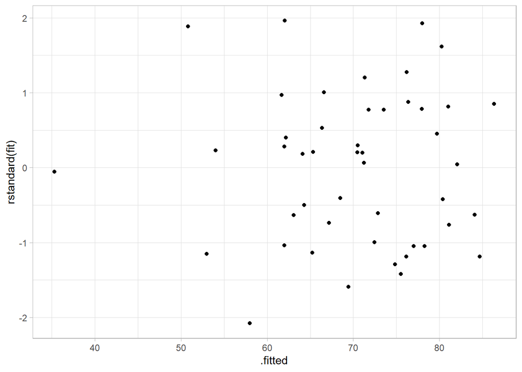

```r
# Standardized residuals
ggplot(data=fit, aes(x=.fitted, y=rstandard(fit))) +
  geom_point() +
  theme_light()
```

### DFBETA

Helps assess how influential each observation is. Essentially calculates how much the slope changes when an observation is removed from the model

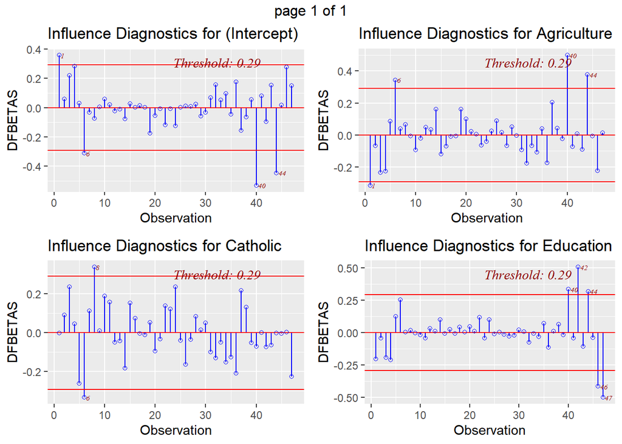

```r
fit <- lm(Fertility ~ Catholic + Agriculture + Education, data = swiss)

ols_plot_dfbetas(fit)
```

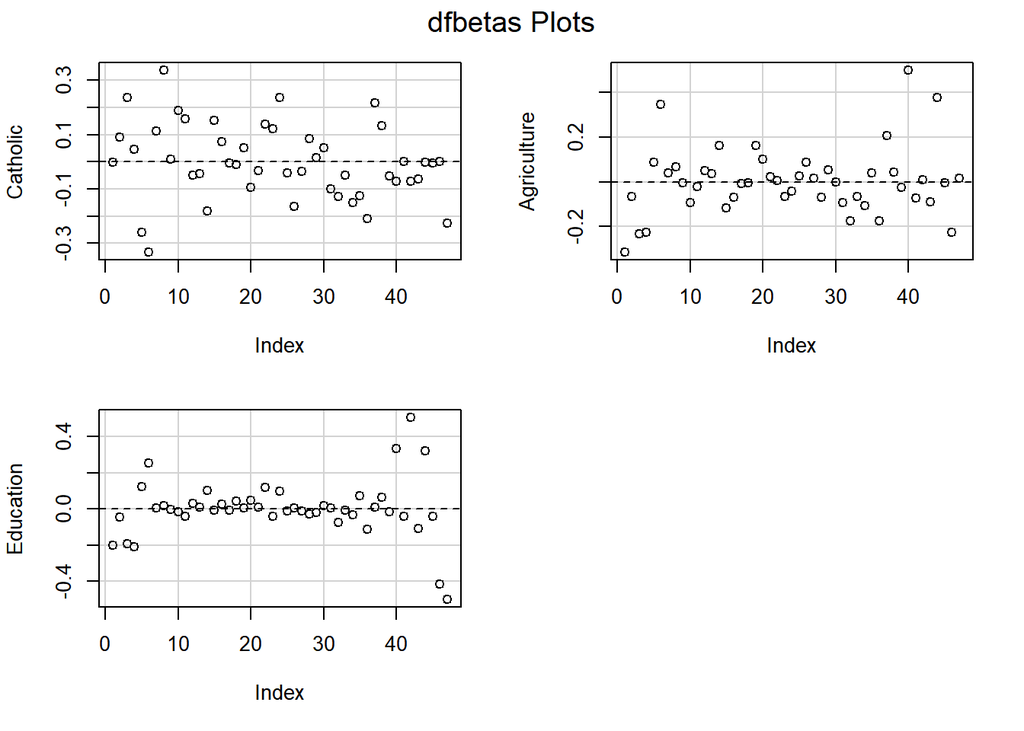

```r
# OR from car

dfbetasPlots(fit)
```

### Cook’s Distance

Tells you how far, on average, the predicted y-values will move if an observation is dropped (note DFBeta is concerned with change in slope but also shows you outliers)

Especially helpful for multivariate regression b/c combos of $X$s could yield an influential point a residual plot won’t catch.

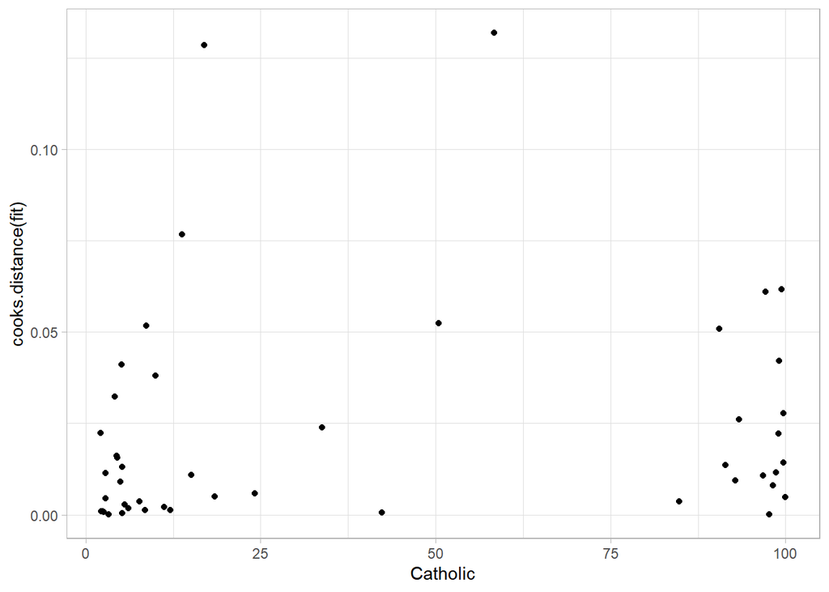

```r
fit <- lm(Fertility ~ Catholic + Agriculture + Education, data = swiss)

ggplot(data=fit, aes(x=Catholic, y=cooks.distance(fit))) +
  geom_point() +
  theme_light()
```

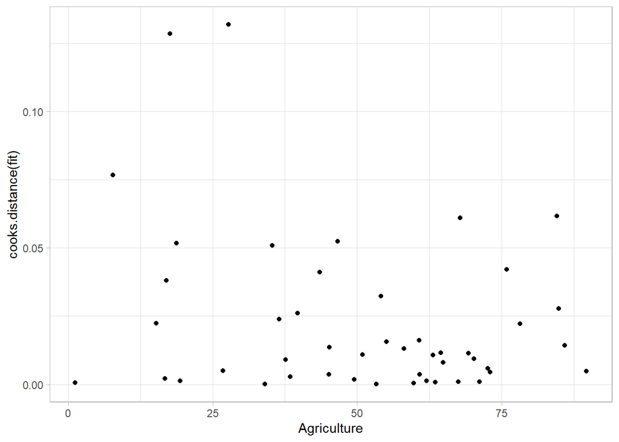

```r
ggplot(data=fit, aes(x=Agriculture, y=cooks.distance(fit))) +
  geom_point() +
  theme_light()
```

### Multicollinearity

The symptoms:

- Instability of estimates when adding or dropping variables
- Massive coefficients or t-statistics
- Two or more variables that are similar but with opposite signs

What do to:

- More data!
- Simplify the model
  - Do we need all the variables that are collinear?
  - Could we combine two or more variables to create some sort of index?

## Instrumental Variables

A type of two-stage least squares regression (2SLS). Normally, when we want to test whether $X$ has some effect on $Y$ we regress $Y$ on $X$ ($Y\sim X$ AKA $Y=X\beta + \epsilon$). However, when $X$ is correlated with the error term (i.e. it is endogenous), $\epsilon$, OLS (and ANOVA) gives biased results. We get around this by using an instrumental variable, $Z$, which is *uncorrelated* with $\epsilon$ and affects $Y$ only through $X$ (i.e. is correlated with $X$ but not with $\epsilon$).

An example in `R`:

We want to estimate the relationship between the after-tax average price of a pack of cigarettes ($X$) on the number of cigarette packs sold per capita ($Y$). We can’t estimate this relationship directly because there is simultaneous causality between supply and demand. However, we can use the sales tax per pack as an instrument ($Z$) as sales tax is correlated with the after-tax price of a pack ($X$) and presumably with the quantity of packs sold ($Y$) but only because sales tax impacts the price per pack.

```r
# Example from: https://www.econometrics-with-r.org/12.1-TIVEWASRAASI.html

data("CigarettesSW")

# Compute real per capita prices (X)
CigarettesSW$rprice <- with(CigarettesSW, price / cpi)

# Compute the sales tax (Z)
CigarettesSW$salestax <- with(CigarettesSW, (taxs - tax) / cpi)

# Check the correlation between Z and X
cor(CigarettesSW$salestax, CigarettesSW$price)
```

```
## [1] 0.6141228
```

```r
# Generate a subset for the year 1995
c1995 <- subset(CigarettesSW, year == "1995")

# Now we estimate the first stage X ~ Z
cig_s1 <- lm(log(rprice) ~ salestax, data = c1995)

summary(cig_s1)
```

```
##
## Call:
## lm(formula = log(rprice) ~ salestax, data = c1995)
##
## Residuals:
##       Min        1Q    Median        3Q       Max
## -0.221027 -0.044324  0.000111  0.063730  0.210717
##
## Coefficients:
##             Estimate Std. Error t value Pr(>|t|)
## (Intercept) 4.616546   0.029108   158.6  < 2e-16 ***
## salestax    0.030729   0.004802     6.4 7.27e-08 ***
## ---
## Signif. codes:  0 '***' 0.001 '**' 0.01 '*' 0.05 '.' 0.1 ' ' 1
##
## Residual standard error: 0.09394 on 46 degrees of freedom
## Multiple R-squared:  0.471,  Adjusted R-squared:  0.4595
## F-statistic: 40.96 on 1 and 46 DF,  p-value: 7.271e-08
```

```r
# Now get the predicted values from our first stage regression
lcigp_pred <- cig_s1$fitted.values

# And regress our Y on our first stage fitted values
cig_s2 <- lm(log(c1995$packs) ~ lcigp_pred)

summary(cig_s2)
```

```
##
## Call:
## lm(formula = log(c1995$packs) ~ lcigp_pred)
##
## Residuals:
##      Min       1Q   Median       3Q      Max
## -0.63180 -0.15802  0.00524  0.13574  0.61434
##
## Coefficients:
##             Estimate Std. Error t value Pr(>|t|)
## (Intercept)   9.7199     1.8012   5.396  2.3e-06 ***
## lcigp_pred   -1.0836     0.3766  -2.877  0.00607 **
## ---
## Signif. codes:  0 '***' 0.001 '**' 0.01 '*' 0.05 '.' 0.1 ' ' 1
##
## Residual standard error: 0.2264 on 46 degrees of freedom
## Multiple R-squared:  0.1525, Adjusted R-squared:  0.1341
## F-statistic: 8.277 on 1 and 46 DF,  p-value: 0.006069
```

```r
# NOTE: the AER package has a function that carries out 2SLS automatically
# ivreg(Y ~ X | Z, data)
cig_ivreg = ivreg(log(packs) ~ log(rprice) | salestax, data = c1995)

summary(cig_ivreg)
```

```
##
## Call:
## ivreg(formula = log(packs) ~ log(rprice) | salestax, data = c1995)
##
## Residuals:
##      Min       1Q   Median       3Q      Max
## -0.64619 -0.07732  0.02981  0.11283  0.41904
##
## Coefficients:
##             Estimate Std. Error t value Pr(>|t|)
## (Intercept)   9.7199     1.5141   6.420 6.79e-08 ***
## log(rprice)  -1.0836     0.3166  -3.422  0.00131 **
## ---
## Signif. codes:  0 '***' 0.001 '**' 0.01 '*' 0.05 '.' 0.1 ' ' 1
##
## Residual standard error: 0.1904 on 46 degrees of freedom
## Multiple R-Squared: 0.4011,  Adjusted R-squared: 0.3881
## Wald test: 11.71 on 1 and 46 DF,  p-value: 0.001313
```

# POLI 271

## Likelihood Theory

### Deriving the log likelihood

Given some probability density function (our stochastic component), $f(y;\theta)$ (could be normal, Gaussian, etc.):

1. Get the joint probability of the data. If the probabilities are independent then we have:

$$Pr(y_i,. . ., y_n|\theta_1, . . ., \theta_n)=Pr(y;\theta)=\prod_{i=1}^nf(y_i;\theta_i)$$

2. Convert the joint probability to a likelihood. Take the joint probability, multiply it by some constant scalar, $h(y)$.

$$\mathcal{L}(\theta|y)=h(y)\times Pr(y;\theta)$$

3. Plug in our $f(y;\theta)$ and simplify $\mathcal{L}(\theta|y)$
4. Simplify further by taking the log of $\mathcal{L}(\theta|y)$
5. Find the critical points by taking the first derivative w.r.t $\theta$
6. Check whether they are maxima or minima by taking the second derivative w.r.t. $\theta$

An example:

The exponential probability density function is defined as: $f_e(x;\theta)=\theta e^{-\theta x}$.

First, note that since $X~f_e(x;\theta)$ the support (possible values of $X$) is $\mathbb{R}\in [0, \infty]$

1. Get the joint probability

$$f_{\mathrm{joint}}(x,\theta)=\prod_{i=1}^n(\theta e^{-\theta x_i})=\theta^n\prod_{i=1}^n( e^{-\theta x_i})$$

2. Define the likelihood function

$$\mathcal{L}(\theta|x)=h(x)\theta^n\prod_{i=1}^n( e^{-\theta x_i})$$

Let $h(x)=1$

$$\mathcal{L}(\theta|x)=\theta^n\prod_{i=1}^n( e^{-\theta x_i})$$

3. Take the log

$$\ln(\mathcal{L}(\theta|x))=\ln(\theta^n\prod_{i=1}^n( e^{-\theta x_i}))$$
$$\ln(\mathcal{L}(\theta|x))=n\ln(\theta)-\theta\sum_{i=1}^nx_i$$

4. Take the first derivative and identify the critical points

$$\frac{d\ln(\mathcal{L}(\theta|x))}{d\theta}=\frac{n}{\theta}-\sum_{i=1}^nx_i$$

Set the derivative equal to zero to find the critical values of $\theta$:

$$\frac{n}{\theta}-\sum_{i=1}^nx_i=0$$

$$\hat{\theta}=\frac{n}{\sum_{i=1}^nx_i}$$

5. Take the second derivative and substitute $\hat{\theta}$ for $\theta$. If the result is positive the critical point is a minumum, if zero then it’s a saddle, if negative it’s a maximum.

$$\frac{d^2\ln(\mathcal{L}(\theta|x))}{d\theta^2}=\frac{-n}{\theta^2}$$

Plugging in $\hat{\theta}$:

$$\frac{d^2ln(\mathcal{L}(\theta=\hat{\theta}|x))}{d\theta^2}=\frac{-n\sum_{i=1}^nx_i}{n}=-\sum_{i=1}^nx_i$$

What’s the sign of $-\sum_{i=1}^nx_i$?

We know $-\sum_{i=1}^nx_i<0$ because $\sum_{i=1}^nx_i>0$ given the $X$ is bounded between $[0, \infty]$ therefore it is a maximum and thus $\hat{\theta}$ is a maximum and the MLE is $\hat{\theta}=\frac{n}{\sum_{i=1}^nx_i}$.

Now in R:

```r
# Sets the seed for R's baked in random number generation for easy replication
set.seed(2)

# Assigns x to be a vector of 1000 observations drawn from the exponential distribution
# with lambda=3
x <- rexp(1000, 3)

# Returns the log likelihood for some parameter, theta, given data, x
exp.ll <- function(theta, x){return((length(x)*log(theta))-(theta*sum(x)))}

thetas = seq(0,25,0.1)

y <- c()

for(theta in thetas){
  y <- c(y,exp.ll(theta=theta,x=x))
}

theta_hat <- length(x)/sum(x)
paste("For the given x, theta_hat is: ", theta_hat)
```

```
## [1] "For the given x, theta_hat is:  2.8956932819183"
```

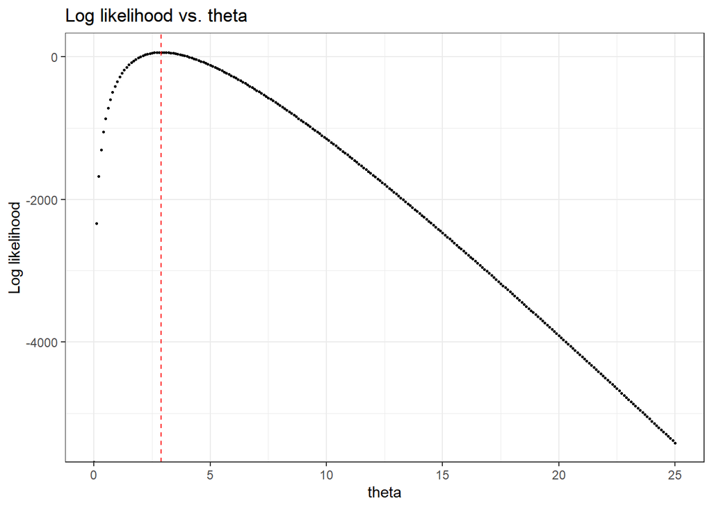

```r
df <- data.frame(y,thetas)

ggplot(data=df,aes(x=thetas,y=y)) +
  geom_point(size=0.5) +
  geom_vline(xintercept=theta_hat, color="red", linetype="dashed") +
  ggtitle("Log likelihood vs. theta") +
  xlab("theta") +
  ylab("Log likelihood") +
  theme_bw()
```

Note: See MLE Problem Set 2 for a derivation of the MLE of the normal variance.

## Regularity

In order to find the MLE as we did above, the likelihood function must demonstrate “regularity”, i.e. it must be continuous and twice differentiable.

## Binary Data

### Why not just use OLS?

- Nonsensical predictions: predicted probabilites using a linear probability model on a binary outcome can fall outside $[0,1]$, meaning the OLS estimate is biased and inconsistent.
- Assumes the relationship between a covariate and the probability of 1 as the outcome is constant across all values of the covariate
- Can give you heteroskedastic residuals that give biased confidence intervals

### The Logit Model

Logit allows for mapping probabilities onto the unbounded real line using odds. We transform a probability, $p$, to logit by taking the log of the odds ratio:

$$\mathrm{logit}(p)=\log(\frac{p}{1-p})$$

And the inverse mapping:

$$\mathrm{logit}^{-1}(x)=\frac{e^x}{1+e^x}=\frac{1}{1+e^{-x}}$$

We model binary outcomes as Bernoulli trials so our stochastic component is:

$$f_B(y_i;\theta_i)=\theta_i^{y_i}(1-\theta_i)^{1-y_i}=
\left\{
\begin{array}{ll}
\theta_i & y_i=1 \\
1-\theta_i & y_i=0
\end{array}
\right.$$

And our systematic component is:

$$\theta_i=\mathrm{logit}^{-1}(x_i^T\beta)=\frac{1}{1+e^{-x_i^T\beta}}$$

As we do above we can then get the joint probability distribution:

$$Pr(y|\theta)=\prod_{i=1}^n \theta_i^{y_i}(1-\theta_i)^{1-y_i}$$

And the log-likelihood:

$$\ln\mathcal{L}(\theta|y)=\sum_{i=1}^n\ln(\frac{e^{-x_i^T\beta^{1-y_i}}}{1+e^{-x_i^T\beta}})$$

Finding the MLE with R (Ward and Ahlquist code):

```r
#function for optimization of logit
binreg<- function(X,y,method="BFGS"){
  X<- cbind(1,X)

  # Get the log-likelihood
  negLL<- function(b,X,y){
    p<-as.vector(1/(1+exp(-X %*% b)))

    return(-sum(y*log(p) + (1-y)*log(1-p)))
  }

  # Get the gradient (score function)
  gradient<- function(b,X,y){
    p <- as.vector(1/(1+exp(-X %*% b)))

    return(-apply(((y - p)*X), 2, sum))
  }

  # Pass our data, log-likelihood, and gradient to optim()
  # which will find the maximum likelihood
  results<- optim(par=rep(0,ncol(X)),
                  fn=negLL,
                  gr=gradient,
                  hessian=T,
                  method=method,
                  X=X,
                  y=y)

  # Pull out the stuff we want
  list(coefficients=results$par,
       stderr=sqrt(diag(solve(results$hessian))),
       var=solve(results$hessian),
       deviance=2*results$value,
       converged=results$convergence==0)
}

data("mtcars")

# set the DV to the binary variable for V-shaped vs. straight engine type
DV <- mtcars$vs

IVs <- as.matrix(mtcars %>% select(cyl, disp, hp))

mlebin.fit<-binreg(X=IVs, y=DV)

# Get our logit coefficients
round(mlebin.fit$coefficients,2)
```

```
## [1] 10.07 -1.08  0.01 -0.04
```

```r
# Compare to R's baked in logit estimation
fit.glm <- glm(vs ~ cyl + disp + hp,
               family = binomial(link = "logit"),
               data = mtcars)
summary(fit.glm, signif.stars=FALSE)
```

```
##
## Call:
## glm(formula = vs ~ cyl + disp + hp, family = binomial(link = "logit"),
##     data = mtcars)
##
## Deviance Residuals:
##      Min        1Q    Median        3Q       Max
## -2.37997  -0.23996  -0.04823   0.35762   1.34781
##
## Coefficients:
##              Estimate Std. Error z value Pr(>|z|)
## (Intercept) 10.069083   3.917828   2.570   0.0102 *
## cyl         -1.075480   1.079346  -0.996   0.3190
## disp         0.008179   0.015662   0.522   0.6015
## hp          -0.043732   0.037350  -1.171   0.2417
## ---
## Signif. codes:  0 '***' 0.001 '**' 0.01 '*' 0.05 '.' 0.1 ' ' 1
##
## (Dispersion parameter for binomial family taken to be 1)
##
##     Null deviance: 43.860  on 31  degrees of freedom
## Residual deviance: 15.758  on 28  degrees of freedom
## AIC: 23.758
##
## Number of Fisher Scoring iterations: 7
```

### Interpreting Logit

While the output of logit is similar to OLS, interpretation is a bit more nuanced for 2 reasons:

1. The model is nonlinear so the effect of a particular covariate on the DV is not constant across all levels of the covariate. This can be seen by deriving the marginal effect of a covariate, $x_k$, on the expected value of $Y$:

$$\frac{\partial E[Y_i]}{\partial x_{ki}}=\frac{\partial\theta_i}{\partial x_{ki}}=\beta_k\frac{e^{x_i^T\beta}}{(1+e^{x_i^T\beta})^2}$$

As a quick trick, you can divide a coefficient by 4 to get an estimate of a maximum effect a 1 unit increase in the covariate can have on the probability of the DV being 1. i.e. if we have a coefficent of -1.45 then $\frac{-1.45}{4}=-0.4$ so a 1 unit increase in the IV reduces the probability of the DV being one by about 40%.

2. The logit model is a linear regression on the log odds so the exponentiated coefficients are odds ratios. If we have a coefficient greater than 1 then a 1 unit increase in that covariate corresponds to an *increase* in the relative probability of obtaining a 1 in the outcome variable. Less than 1 represents a decrease.

### Interpreting Logit with Plots

We can use a coefficient plot to avoid a BUTON

```r
# Read in and clean up the data
impeach <- read_csv("Data/impeach.csv")
#impeach <- impeach %>% select(-ccoal98)
impeach <- na.omit(impeach)
attach(impeach)

# Make our DV binary
impeach$votebin[votesum != 0] <- 1
impeach$votebin[votesum == 0] <- 0

# Estimate the model
model <- glm(votebin ~ partyid + clint96, family=binomial(link="logit"), data=impeach)

summary(model)
```

```
##
## Call:
## glm(formula = votebin ~ partyid + clint96, family = binomial(link = "logit"),
##     data = impeach)
##
## Deviance Residuals:
##     Min       1Q   Median       3Q      Max
## -3.2606  -0.0414   0.0128   0.0848   2.5753
##
## Coefficients:
##             Estimate Std. Error z value Pr(>|z|)
## (Intercept) 11.22019    3.25291   3.449 0.000562 ***
## partyid      7.95961    1.03158   7.716 1.20e-14 ***
## clint96     -0.31520    0.07542  -4.179 2.92e-05 ***
## ---
## Signif. codes:  0 '***' 0.001 '**' 0.01 '*' 0.05 '.' 0.1 ' ' 1
##
## (Dispersion parameter for binomial family taken to be 1)
##
##     Null deviance: 593.487  on 428  degrees of freedom
## Residual deviance:  57.753  on 426  degrees of freedom
## AIC: 63.753
##
## Number of Fisher Scoring iterations: 9
```

```r
# Tidy the model
results <- tidy(model)

# Get the 95% CI
fit_cis_95 <- confint(model, level = 0.95) %>%
  data.frame() %>%
  rename("conf.low_95" = "X2.5..",
         "conf.high_95" = "X97.5..")
# Get the 90% CI
fit_cis_90 <- confint(model, level = 0.90) %>%
  data.frame() %>%
  rename("conf.low_90" = "X5..",
         "conf.high_90" = "X95..")
```

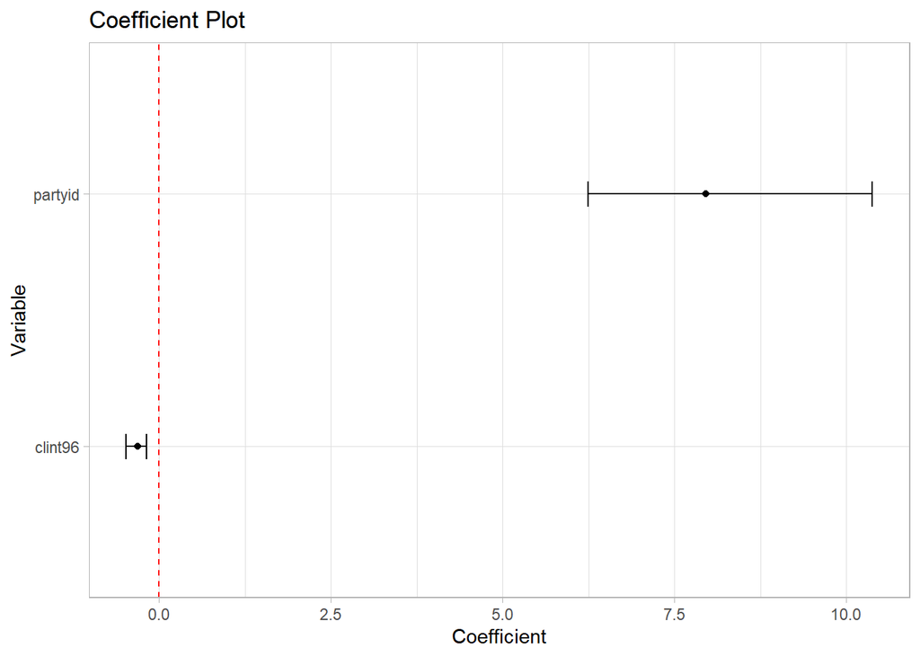

```r
# Bind it together
results <- bind_cols(results,
                     fit_cis_95,
                     fit_cis_90) %>%
           rename(Variable = term,
                  Coefficient = estimate,
                  SE = std.error) %>%
           filter(Variable != "(Intercept)")

# Plot it!
ggplot(results, aes(x = Variable, y = Coefficient)) +
        geom_hline(yintercept = 0, color = "red", lty = 2) +
        geom_point(aes(x = Variable,
                    y = Coefficient)) +
        # geom_linerange(aes(x = Variable,
        #              ymin = conf.low_90,
        #              ymax = conf.high_90),
        #            lwd = 1) +
        geom_errorbar(aes(x = Variable,
                     ymin = conf.low_95,
                     ymax = conf.high_95),
                     width=.1) +
        ggtitle("Coefficient Plot") +
        coord_flip() +
  theme_light()
```

We can use a predicted probability plot to show the substantive impact of our results

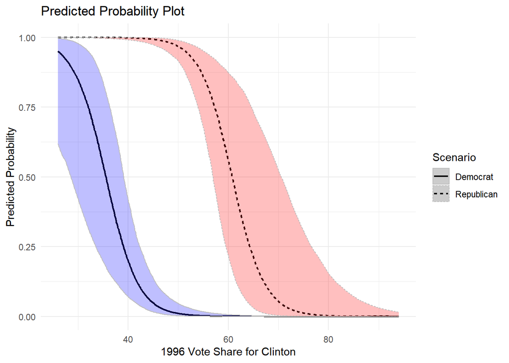

```r
# Say we want to know the difference in predicted probability
# of a Republican vs. a Democrat voting to impeach Clinton

# Create a sequence of the range of values for the 96 vote share
clint96.range <- seq(min(impeach$clint96),max(impeach$clint96),.1)

# Construct the Democratic scenario
x.lo <- c(1, 0, median(impeach$clint96)) # Democrat scenario
X.lo <- matrix(x.lo, nrow=length(x.lo), ncol=length(clint96.range))
X.lo[3,] <- clint96.range

# Construct the Republican scenario
x.hi <- c(1, 1, median(impeach$clint96)) # Republican scenario
X.hi <- matrix(x.hi, nrow=length(x.hi), ncol=length(clint96.range))
X.hi[3,] <- clint96.range

# Generate a multivariate normal distribution
B.tilde <- mvrnorm(1000, coef(model), vcov(model))

# Generate the predicted probabilities
s.lo <- inv.logit(B.tilde %*% X.lo)
s.hi <- inv.logit(B.tilde %*% X.hi)
s.lo <- apply(s.lo, 2, quantile, c(0.025, 0.5, 0.975))
s.hi <- apply(s.hi, 2, quantile, c(0.025, 0.5, 0.975))


# Now tidy the data and plot with ggplot
pred.prob.df <- data.frame(xrange=rep(clint96.range,2),
                           y=c(s.lo[2,],s.hi[2,]),
                           conf.low = c(s.lo[1,], s.hi[1,]),
                           conf.high = c(s.lo[3,], s.hi[3,]),
                           scenario = rep(c("Democrat", "Republican"),
                                          each=length(clint96.range)))

ggplot(data=pred.prob.df, aes(x=xrange, y=y,
                              ymin=conf.low,
                              ymax=conf.high,
                              fill=factor(scenario),
                              linetype=factor(scenario))) +
  geom_line(size=.8) +
  geom_ribbon(alpha=0.25, color="gray") +
  labs(x="1996 Vote Share for Clinton", y="Predicted Probability",
       title="Predicted Probability Plot", linetype="Scenario") +
  scale_fill_manual(labels=c("Democrat", "Republican"),
                    values=c("blue", "red")) +
  theme_minimal() +
  guides(fill="none", color="none")
```

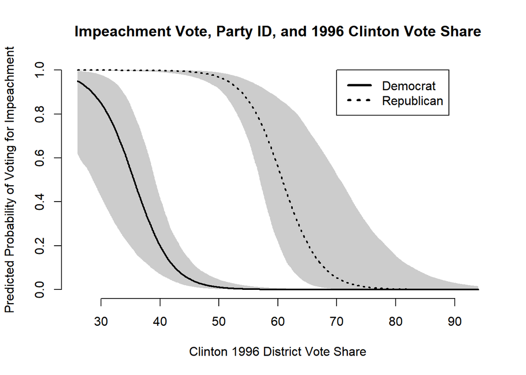

```r
# Or use base graphics (ew)

#jpeg(file="pred_prob.jpeg")

# Get our blank plot
plot(clint96.range, s.lo[2,], ylim=c(0,1),
     xlab="Clinton 1996 District Vote Share",
     ylab="Predicted Probability of Voting for Impeachment",
     main="Impeachment Vote, Party ID, and 1996 Clinton Vote Share",
     bty="n", col="white")

# Plot the confidence bands
polygon(x=c(clint96.range, rev(clint96.range)),
        y=c(s.lo[1,],rev(s.lo[3,])),
        col=grey(0.8), border=NA)

polygon(x=c(clint96.range, rev(clint96.range)),
        y=c(s.hi[1,],rev(s.hi[3,])),
        col=grey(0.8), border=NA)

#Plot the predicted probability curves
lines(clint96.range, s.hi[2,], lty=3, lwd=2)

lines(clint96.range, s.lo[2,], lwd=2)

legend(70, 1, legend=c("Democrat", "Republican"), lty=c(1,3),lwd=3)
```

```r
#dev.off()
```

We can also use a predicted probability plot to model an interaction in a logit model

```r
# Load in the data
impeach <- read_csv("Data/impeach.csv")
impeach <- impeach %>% na.omit()

impeach$votebin[impeach$votesum != 0] <- 1
impeach$votebin[impeach$votesum == 0] <- 0

model_int <- glm(votebin ~ clint96 * aflcio97 ,family=binomial(link="logit"),
                 data=impeach)
model_noint <- glm(votebin ~ clint96 + aflcio97,
                   family=binomial(link="logit"),
                   data=impeach)

modelsummary(list(model_noint, model_int), title="Impeachment models")
```

Impeachment models

|  | Model 1 | Model 2 |
| --- | --- | --- |
| (Intercept) | 10.344 | 14.946 |
|  | (2.969) | (9.954) |
| clint96 | -0.060 | -0.152 |
|  | (0.059) | (0.197) |
| aflcio97 | -0.122 | -0.182 |
|  | (0.016) | (0.122) |
| clint96 × aflcio97 |  | 0.001 |
|  |  | (0.002) |
| Num.Obs. | 429 | 429 |
| AIC | 83.3 | 85.0 |
| BIC | 95.5 | 101.3 |
| Log.Lik. | -38.648 | -38.517 |

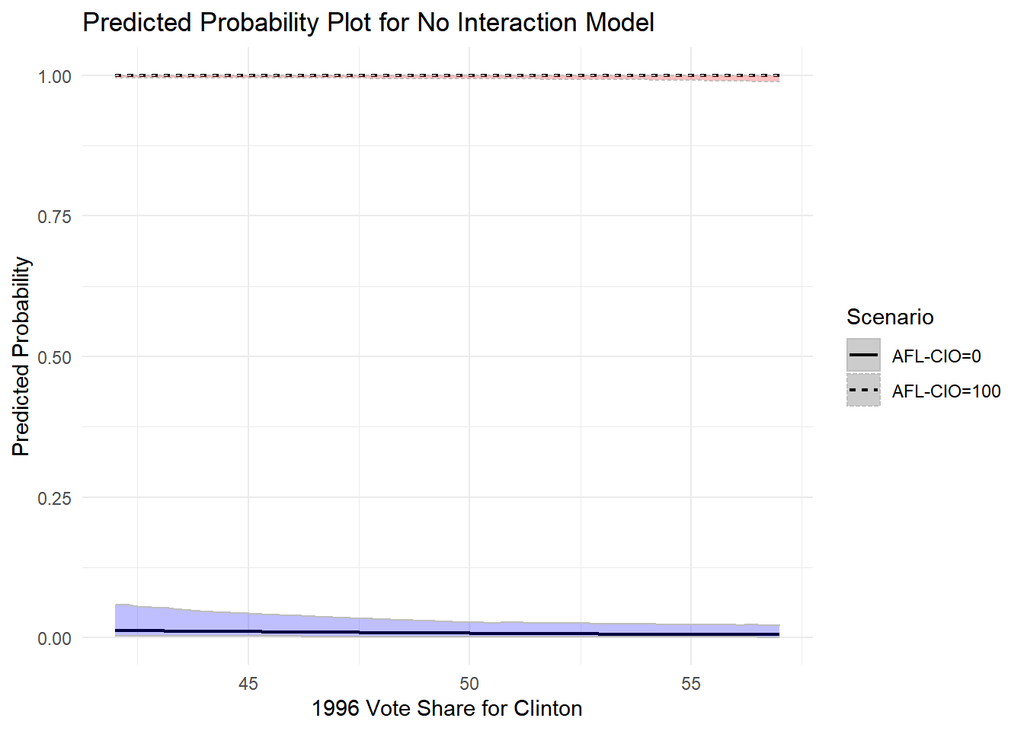

```r
clint96.range <- seq(quantile(impeach$clint96)[2],
                    quantile(impeach$clint96)[4],.1)

# NO INTERACTION MODEL
x.lo <- c(1, median(impeach$clint96), 0) # Q1 clint96 scenario
X.lo <- matrix(x.lo, nrow=length(x.lo), ncol=length(clint96.range))
X.lo[2,] <- clint96.range

x.hi <- c(1, median(impeach$clint96), 100) # Q2 clint96 scenario
X.hi <- matrix(x.hi, nrow=length(x.hi), ncol=length(clint96.range))
X.hi[2,] <- clint96.range

B.tilde <- mvrnorm(1000, coef(model_noint), vcov(model_noint))

s.lo <- inv.logit(B.tilde %*% X.lo) # Note we would use pnorm() here instead if
s.hi <- inv.logit(B.tilde %*% X.hi) # evaluating a probit model!

s.lo <- apply(s.lo, 2, quantile, c(0.025, 0.5, 0.975))
s.hi <- apply(s.hi, 2, quantile, c(0.025, 0.5, 0.975))


# Now tidy the data and plot with ggplot
pred.prob.df.noint <- data.frame(xrange=rep(clint96.range,2),
                           y=c(s.lo[2,],s.hi[2,]),
                           conf.low = c(s.lo[1,], s.hi[1,]),
                           conf.high = c(s.lo[3,], s.hi[3,]),
                           scenario = rep(c("AFL-CIO=100", "AFL-CIO=0"),
                                          each=length(clint96.range)))

ggplot(data=pred.prob.df.noint, aes(x=xrange, y=y,
                              ymin=conf.low,
                              ymax=conf.high,
                              fill=factor(scenario),
                              linetype=factor(scenario))) +
  geom_line(size=.8) +
  geom_ribbon(alpha=0.25, color="gray") +
  labs(x="1996 Vote Share for Clinton", y="Predicted Probability",
       title="Predicted Probability Plot for No Interaction Model", linetype="Scenario") +
  scale_fill_manual(labels=c("AFL-CIO=100", "AFL-CIO=0"),
                    values=c("blue", "red")) +
  theme_minimal() +
  guides(fill="none", color="none")
```

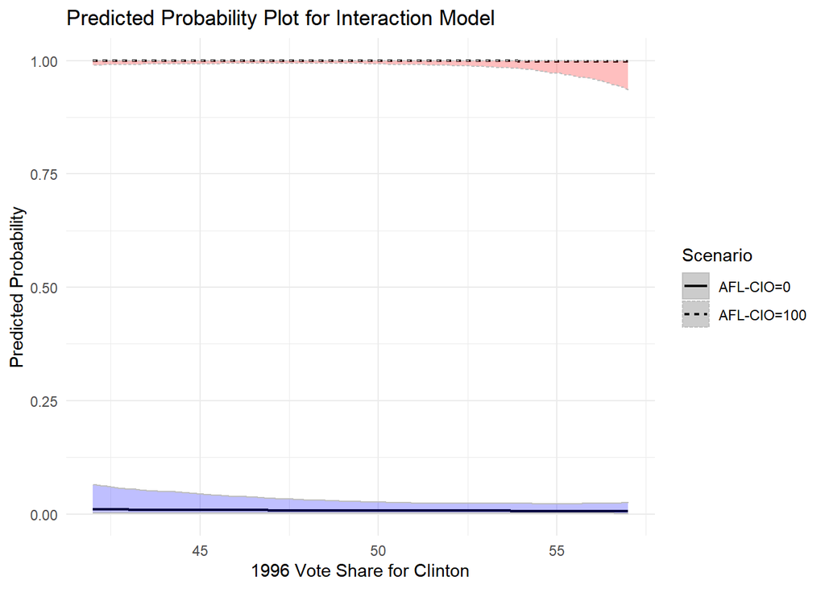

```r
# INTERACTION MODEL
x.lo <- c(1, median(impeach$clint96)[2], 0, 0) # 0 AFL-CIO score scenario
X.lo <- matrix(x.lo, nrow=length(x.lo), ncol=length(clint96.range))
X.lo[2,] <- clint96.range
X.lo[4,] <- clint96.range*0

x.hi <- c(1, quantile(impeach$clint96)[4], 100, 0) # 100 AFL-CIO score scenario
X.hi <- matrix(x.hi, nrow=length(x.hi), ncol=length(clint96.range))
X.hi[2,] <- clint96.range
X.hi[4,] <- clint96.range*100

B.tilde <- mvrnorm(1000, coef(model_int), vcov(model_int))

s.lo <- inv.logit(B.tilde %*% X.lo)
s.hi <- inv.logit(B.tilde %*% X.hi)

s.lo <- apply(s.lo, 2, quantile, c(0.025, 0.5, 0.975))
s.hi <- apply(s.hi, 2, quantile, c(0.025, 0.5, 0.975))


# Now tidy the data and plot with ggplot
pred.prob.df.int <- data.frame(xrange=rep(clint96.range,2),
                           y=c(s.lo[2,],s.hi[2,]),
                           conf.low = c(s.lo[1,], s.hi[1,]),
                           conf.high = c(s.lo[3,], s.hi[3,]),
                           scenario = rep(c("AFL-CIO=100", "AFL-CIO=0"),
                                          each=length(clint96.range)))

ggplot(data=pred.prob.df.int, aes(x=xrange, y=y,
                              ymin=conf.low,
                              ymax=conf.high,
                              fill=factor(scenario),
                              linetype=factor(scenario))) +
  geom_line(size=.8) +
  geom_ribbon(alpha=0.25, color="gray") +
  labs(x="1996 Vote Share for Clinton", y="Predicted Probability",
       title="Predicted Probability Plot for Interaction Model", linetype="Scenario") +
  scale_fill_manual(labels=c("AFL-CIO=100", "AFL-CIO=0"),
                    values=c("blue", "red")) +
  theme_minimal() +
  guides(fill="none", color="none")
```

### ROC Plots

In the below example, because the simpler model performs about as well as the more complicated one we would opt for the simpler model (assuming AIC, BIC, etc. are similar)

```r
# Read in and clean up the data
impeach <- read_csv("Data/impeach.csv")
impeach <- na.omit(impeach)
attach(impeach)
# Make our DV binary
impeach$votebin[votesum != 0] <- 1
```

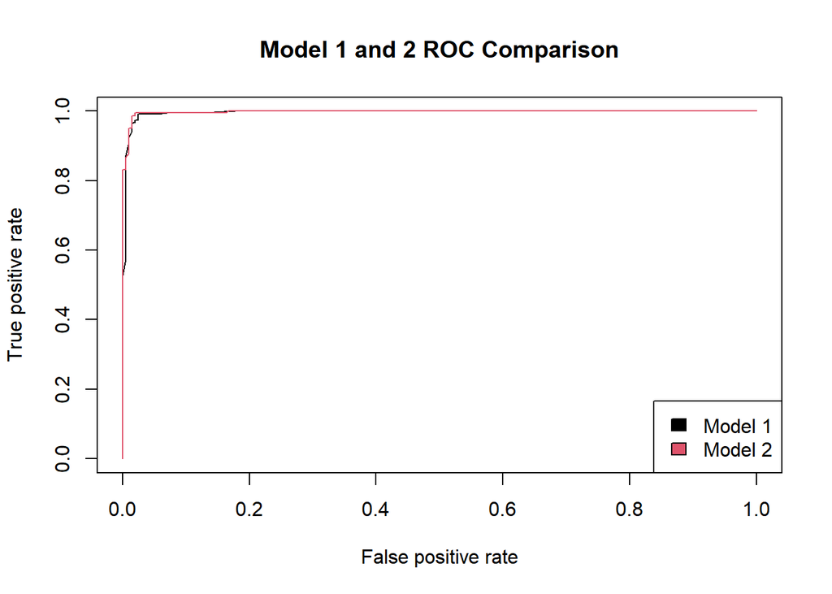

```r
impeach$votebin[votesum == 0] <- 0

# Define two models to compare, one without aflcio97, one with
model1 <- glm(votebin ~ partyid + clint96, family=binomial(link="logit"), data=impeach)

model2 <- glm(votebin ~ partyid + clint96 + aflcio97, family=binomial(link="logit"), data=impeach)

# Get out predicted values for each model
model1_pred <- predict(model1, impeach, type = "response")
model2_pred <- predict(model2, impeach, type = "response")
preds_list <- cbind(model1_pred, model2_pred)


m <- length(preds_list)
actual_values <- rep(list(impeach$votebin),2)

pred <- prediction(preds_list, actual_values)
rocs <- performance(pred, "tpr", "fpr")
#jpeg(file="ROCplot.jpeg")

# Plot it
plot(rocs, col = as.list(1:m), main = "Model 1 and 2 ROC Comparison")
     legend(x = "bottomright",
            legend = c("Model 1", "Model 2"),
            fill = 1:m)
```

```r
#dev.off()

# Calculating the AUC from the predicted values calculated above
AUC_in <- performance(pred, measure="auc")

AUC_labels <- c("Model 1", "Model 2")

knitr::kable(cbind(AUC_labels, round(as.numeric(AUC_in@y.values), 3)), col.names = c("", "AUC"),
      caption = "Model AUCs")
```

Model AUCs

|  | AUC |
| --- | --- |
| Model 1 | 0.996 |
| Model 2 | 0.998 |